# Epidemiology of Pneumonia and Influenza in most densely populated states in USA from 1988-2014

We will start with the flu process.

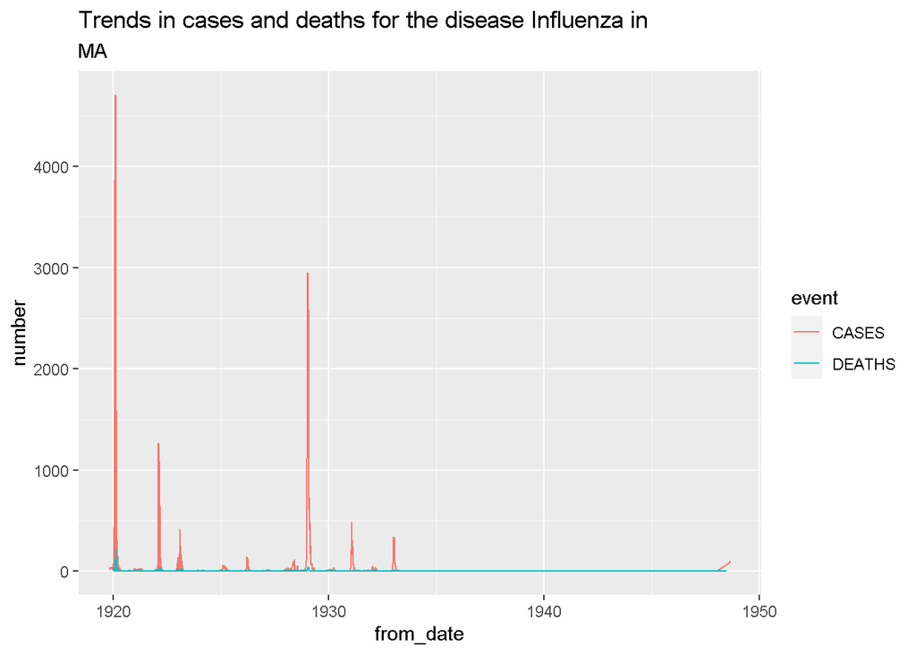

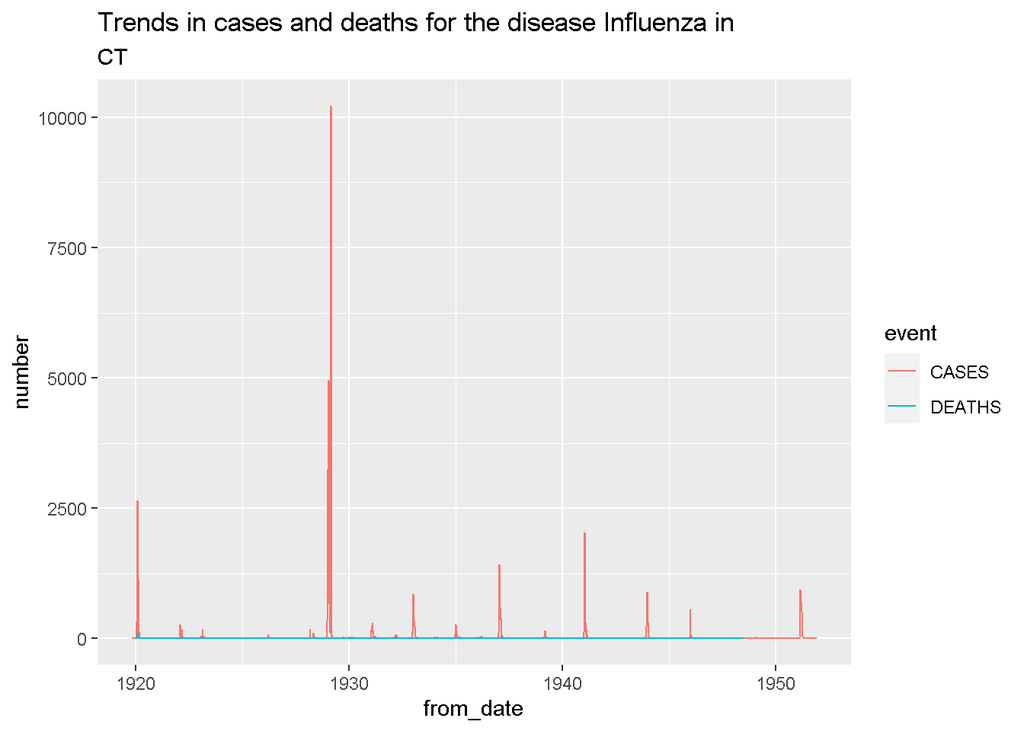

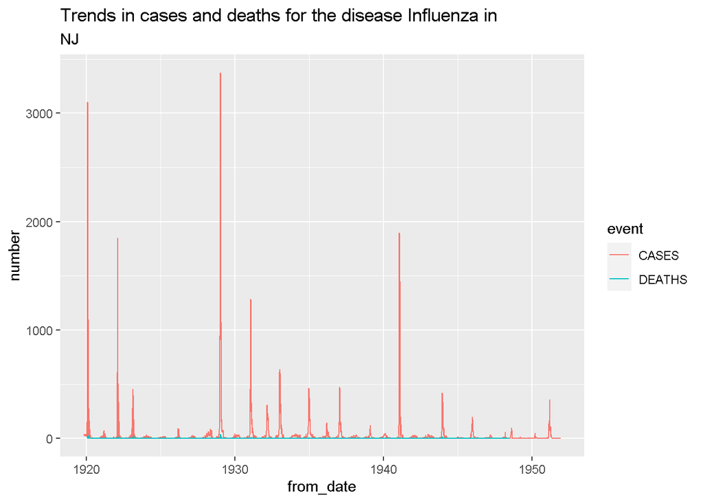

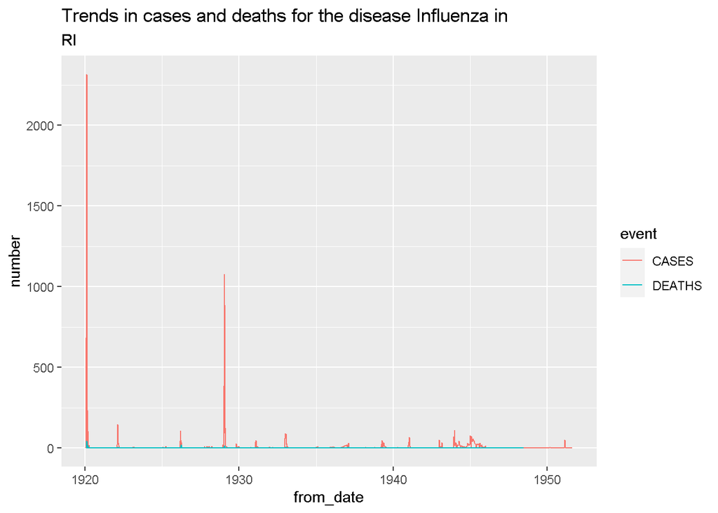

```r
for(st in states){
  print(ggplot(filter(data_infl, state == st), aes(x = from_date, y = number)) +
    geom_line(
      aes(color = event),
      stat = "identity", position = position_stack()
      ) + ggtitle("Trends in cases and deaths for the disease Influenza in",st))
}
```

The spike we can see in each region around 1920 is due to the H1N1 virus. The 1918 flu epidemic was the worst pandemic in recent history. It was caused by the H1N1 virus, which has a genetic predisposition to birds.

The first graph is for Masachussets. Here, a negative trend is seen, that is good for the people of the state. This practice suggests that the development of the medical field has effectively reduced the spread of the disease. The death toll is now very close to zero after those peaks were seen in the flu pandemic. After the spike in about 1920, a few more pins were seen between 1920 and 1925, before 1930 and after 1930. No spikes were detected after 1935 in the state Masachussets.

The second graph is for the Connecticut region. In this case too, the spike was observed in about 1920. Then another was discovered before 1930 and the largest in the region during that time, followed by small spikes to the end.

New Jersey has a large number of spikes that suggest a major flu outbreak, the first visible spike seen around 1920, followed by two more before 1925 and one just before 1930 to more than one before 1920. Another large speaker was spotted. after 1940.

The death toll was relatively low compared to the number of cases and there were not many incidents.

Obtaining time graphs compared with the number of cases and deaths of Pneumonia in the four provinces.

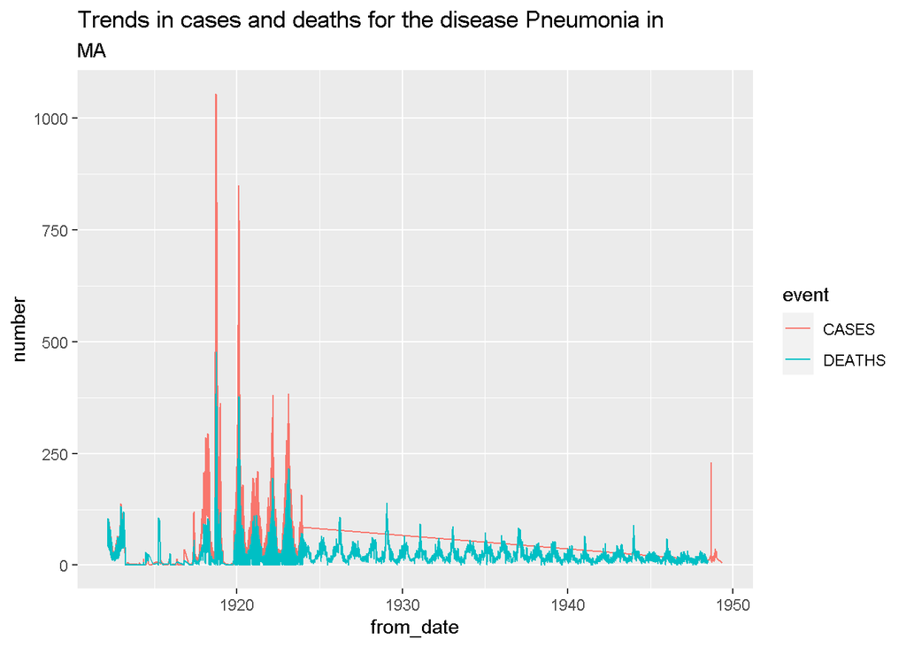

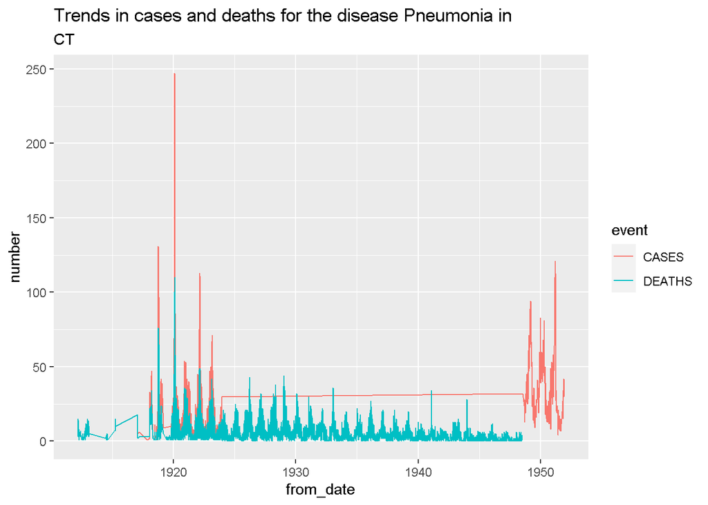

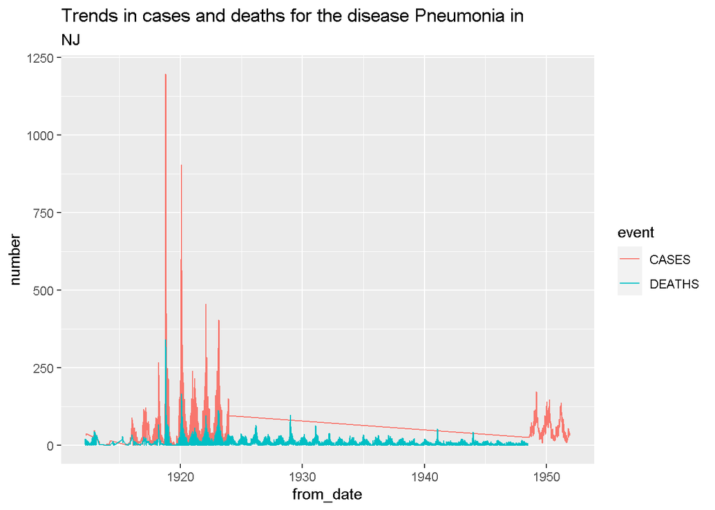

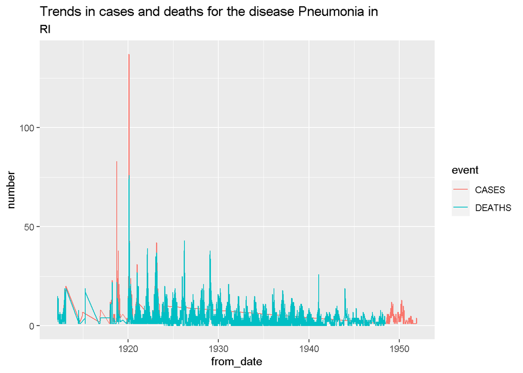

```r
for(st in states){
  print(ggplot(filter(data_pneu, state == st), aes(x = from_date, y = number)) +
    geom_line(
      aes(color = event),
      stat = "identity", position = position_stack()
      ) + ggtitle("Trends in cases and deaths for the disease Pneumonia in",st))
}
```

Following points can be made looking at the graphs:

Starting with the Massachusset, it is noted that at the beginning of the timeline the death toll was equal to the number of cases of pneumonia which was probably due to the lack of healthcare support. somewhere in about 1917 the number of cases and deaths increased but in this case the deaths were less than the cases detected. After that another high figure appears about 1918 which is the longest in the graph with the highest number of cases and deaths in history. It is followed by another high rate starting since 1920 with high rates and deaths. After that spike trend seemed to subside and end with a spike at the end, it had no details of death.

The Connecticut graph shows six spikes about 1920 and the second is the longest with the highest number of cases and fatalities. After these six criminals the graph stays just over 25 numbers and occasionally rises to death. The graph concludes with a few additional peaks / peaks at the end and no death value data is detected.

Next comes New Jersey with many pegs focused between 1915 and 1925 and about 1950. The first large spike appeared in about 1918 which occurred the longest, followed by the one seen in 1920. After that it seems to follow a very small peak. with two larger peaks, the first with less death than the latter. The graph ends with a few spikes before following a direct drop. The number of deaths after 1930 did not increase as much as it did before promoting development in the health sector.

In the illustrated introduction to the case, mortality versus time, it is noted that the average number of cases across a given timeline remains low compared to other states. The graph begins with a high mortality rate and completely closed cases that suggest that the number of patients with the disease at the time seemed as incurable as most new diseases. When we arrived in 1920, two spikes began to occur about 1918 and another in the early 1920’s, in this case the death toll was lower compared to the number of cases recorded. After that, while the number of recorded cases dropped, the death toll continued to rise from time to time until 1935, after which it also began to decline. Also, no death-related data at the end of the timeline was found, with small case spikes detected.

If we compare the graphs of Pneumonia with Influenza’s, it can be stated that while the number of deaths remained high for Pneumonia, deaths recorded in Influenza mostly stayed low as it is not a fatal disease if take a good care. However, its more contagious so the number of cases are generally high for Influenza.

To conclude, Every states no matter at what scale the cases were observed, a general trend is observed with negative nature throughout the timeline for both the diseases. It seems the numbers will further fall looking at the current advancements in the healthcare sector.

### **References:**

- https://publichealthreviews.biomedcentral.com/articles/10.1007/BF03391605
- https://www.ncbi.nlm.nih.gov/books/NBK22148/
- https://www.ncdemography.org/2014/06/16/mortality-and-cause-of-death-1900-v-2010/
- https://www.webmd.com/lung/complications-pneumonia
- https://familydoctor.org/condition/pneumonia/